# Diamond Value Predictor Shiny App

05/10/2019

## What is the app?

This Shiny App estimates the value of a diamond with the characteristics specified by the user. The characteristics that user can choose are as following:

1. Diamond Cut Quality: Ideal, Premium, Very Good, Good, Fair
2. Diamond Color: J, I, H, G, F, E, D
3. Diamond Clarity: IF, VVS1, VVS2, VS1, VS2, SI1, SI2, I1
4. Diamond Weight in carats: 0.2-2.5 carats

Using the above-mentioned inputs, the app uses a dataset in R named “diamonds” to fit a linear model and estimate the value of the diamond.

## The Dateset

The `diamond` dataset in R can be found in the `ggplot2` package. Below a brief summary of the dataset is shown:

```
# A tibble: 4 x 5
  carat cut     color clarity price
  <dbl> <ord>   <ord> <ord>   <int>
1 0.23  Ideal   E     SI2       326
2 0.21  Premium E     SI1       326
3 0.23  Good    E     VS1       327
4 0.290 Premium I     VS2       334
```

```
     carat               cut        color        clarity
 Min.   :0.2000   Fair     : 1610   D: 6775   SI1    :13065
 1st Qu.:0.4000   Good     : 4906   E: 9797   VS2    :12258
 Median :0.7000   Very Good:12082   F: 9542   SI2    : 9194
 Mean   :0.7979   Premium  :13791   G:11292   VS1    : 8171
 3rd Qu.:1.0400   Ideal    :21551   H: 8304   VVS2   : 5066
 Max.   :5.0100                     I: 5422   VVS1   : 3655
                                    J: 2808   (Other): 2531
     price
 Min.   :  326
 1st Qu.:  950
 Median : 2401
 Mean   : 3933
 3rd Qu.: 5324
 Max.   :18823
```

## The App

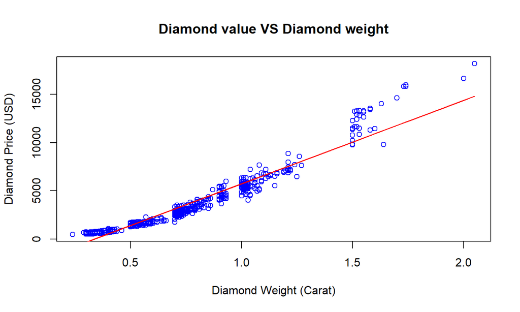

## Links

Access the app via the below link:  
[Diamond Value Predictor App](https://pourkhesalian.shinyapps.io/DiamondPricePredictor/)

Github link to app source code:  
[Diamond Value App source](https://github.com/pourkhesalian/Shiny-Application-and-Reproducible-Pitch)

This presentation in Github:  
[The presentation](https://pourkhesalian.github.io/Shiny-Application-and-Reproducible-Pitch/DiamondPricePredictorPitch.html#1)